# Wines of the PNW

Author

Summer Tucker

Published

February 3, 2025

#Abstract:

This is a technical blog post of **both** an HTML file *and* .qmd file hosted on GitHub pages.

**Set Up Code:**

```r
library(tidyverse)
library(caret)
library(fastDummies)
library(randomForest)
wine <- readRDS(gzcon(url("https://github.com/cd-public/D505/raw/master/dat/wine.rds")))
```

**Explanation of set up code:**

> TODO: *Line 1: Loads the tidyverse package Line 2: Loads the caret package Line 3: Loads the fastDummies package Line 4: Loads the randomForest package Line 5: Reads in the wine data from a url.*

# Feature Engineering

We begin by engineering an number of features.

1. Create a total of 10 features (including points).
2. Remove all rows with a missing value.
3. Ensure only log(price) and engineering features are the only columns that remain in the `wino` dataframe.

```r
#Creating 10 features, dropping rows with a missing value, selecting only log(price) and the other 10 features

wino <- wine %>%
  mutate(region_1 = fct_lump(region_1, 5)) %>%
  mutate(variety = fct_lump(variety, 4)) %>%
  mutate(lprice = log(price)) %>%
  select(lprice, points, region_1, variety) %>%
  drop_na(.)
head(wino)
```

```
# A tibble: 6 × 4
  lprice points region_1          variety
   <dbl>  <dbl> <fct>             <fct>
1   2.64     87 Willamette Valley Other
2   2.56     87 Other             Other
3   4.17     87 Willamette Valley Pinot Noir
4   2.71     87 Other             Other
5   2.77     87 Other             Other
6   3.18     87 Alsace            Other
```

```r
renamer <- function(s) {
  s %>% tolower() %>% str_replace("-| ", "_")
}

wino <- wino %>%
  dummy_cols(remove_selected_columns = TRUE) %>%
  rename_with(.fn = renamer) %>%
  select(-ends_with("other"))
head(wino)
```

```
# A tibble: 6 × 11
  lprice points region_1_alsace `region_1_columbia_valley (wa)` region_1_mendoza
   <dbl>  <dbl>           <int>                           <int>            <int>
1   2.64     87               0                               0                0
2   2.56     87               0                               0                0
3   4.17     87               0                               0                0
4   2.71     87               0                               0                0
5   2.77     87               0                               0                0
6   3.18     87               1                               0                0
# ℹ 6 more variables: region_1_napa_valley <int>,
#   region_1_willamette_valley <int>, variety_cabernet_sauvignon <int>,
#   variety_chardonnay <int>, variety_pinot_noir <int>, variety_red_blend <int>
```

# Caret

We now use a train/test split to evaluate the features.

1. Use the Caret library to partition the wino dataframe into an 80/20 split.
2. Run a linear regression with bootstrap resampling.
3. Report RMSE on the test partition of the data.

```r
# Partitioning wino dataframe

wine_index <- createDataPartition(wino$lprice, p = 0.8, list = FALSE)
wino_tr <- wino[wine_index, ]
wino_te <- wino[-wine_index, ]
```

```r
#Creating a linear regression model with bootstrap resamping (training partition)

w_train_model <- train(lprice ~ .,
  data = wino_tr,
  method = "lm",
  trControl = trainControl(method = "boot", number = 25)
)

# Finding RMSE of test partition

postResample(
  pred = predict(w_train_model, wino_te),
  obs = wino_te$lprice
)
```

```
     RMSE  Rsquared       MAE
0.4917645 0.4172585 0.3852255
```

# Variable selection

We now graph the importance of your 10 features.

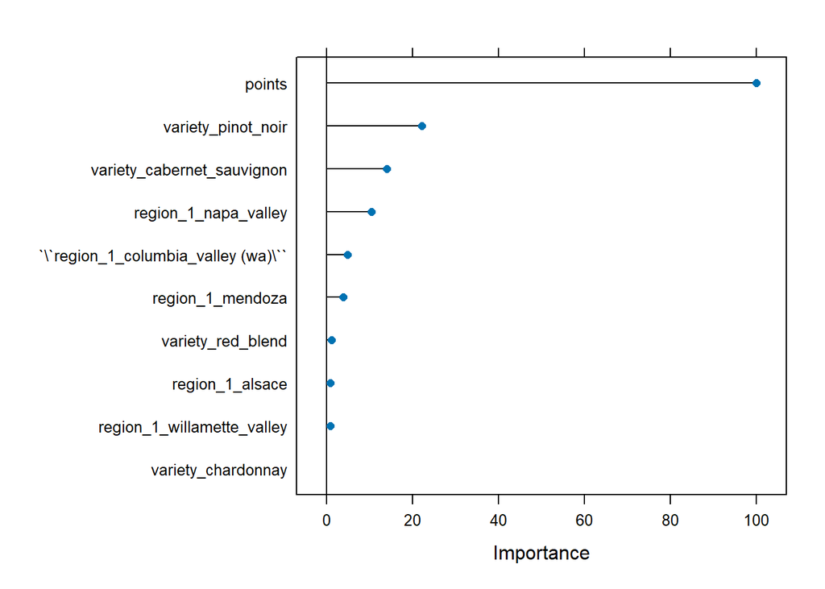

```r
# TODO:
plot(varImp(w_train_model, scale = TRUE))
```